# titanic_pandas

## Nicholas Cica

August 2016

Project 2

Data Analyst Nano Degree

Dataset: Titanic

```python
# Import Magic
import pandas as pd
from pandas import DataFrame
import matplotlib.pyplot as plt
import numpy as np
import seaborn as sns
%pylab inline
```

## Load Data from CSVs

```python
# DateFrames are great for representing CSVs!
# This helps us get a good look at the data and how it is organized.
manifest = pd.read_csv('titanic_data.csv')
manifest.head()
```

|  | PassengerId | Survived | Pclass | Name | Sex | Age | SibSp | Parch | Ticket | Fare | Cabin | Embarked |
| --- | --- | --- | --- | --- | --- | --- | --- | --- | --- | --- | --- | --- |
| 0 | 1 | 0 | 3 | Braund, Mr. Owen Harris | male | 22.0 | 1 | 0 | A/5 21171 | 7.2500 | NaN | S |
| 1 | 2 | 1 | 1 | Cumings, Mrs. John Bradley (Florence Briggs Th... | female | 38.0 | 1 | 0 | PC 17599 | 71.2833 | C85 | C |
| 2 | 3 | 1 | 3 | Heikkinen, Miss. Laina | female | 26.0 | 0 | 0 | STON/O2. 3101282 | 7.9250 | NaN | S |
| 3 | 4 | 1 | 1 | Futrelle, Mrs. Jacques Heath (Lily May Peel) | female | 35.0 | 1 | 0 | 113803 | 53.1000 | C123 | S |
| 4 | 5 | 0 | 3 | Allen, Mr. William Henry | male | 35.0 | 0 | 0 | 373450 | 8.0500 | NaN | S |

## Investigate the Data

```python
# Let's check the data types
type(manifest)
manifest.dtypes
```

```
PassengerId      int64
Survived         int64
Pclass           int64
Name            object
Sex             object
Age            float64
SibSp            int64
Parch            int64
Ticket          object
Fare           float64
Cabin           object
Embarked        object
dtype: object
```

```python
# Let's take a look at the totals
manifest.info()
# Looks like we are missing some Age and Cabin data
```

```
<class 'pandas.core.frame.DataFrame'>
RangeIndex: 891 entries, 0 to 890
Data columns (total 12 columns):
PassengerId    891 non-null int64
Survived       891 non-null int64
Pclass         891 non-null int64
Name           891 non-null object
Sex            891 non-null object
Age            714 non-null float64
SibSp          891 non-null int64
Parch          891 non-null int64
Ticket         891 non-null object
Fare           891 non-null float64
Cabin          204 non-null object
Embarked       889 non-null object
dtypes: float64(2), int64(5), object(5)
memory usage: 83.6+ KB
```

```python
# Summary of the Data
# This helps us get a broad understanding of the data by looking at
# how the values are distribued.
manifest.describe()
```

|  | PassengerId | Survived | Pclass | Age | SibSp | Parch | Fare |
| --- | --- | --- | --- | --- | --- | --- | --- |
| count | 891.000000 | 891.000000 | 891.000000 | 714.000000 | 891.000000 | 891.000000 | 891.000000 |
| mean | 446.000000 | 0.383838 | 2.308642 | 29.699118 | 0.523008 | 0.381594 | 32.204208 |
| std | 257.353842 | 0.486592 | 0.836071 | 14.526497 | 1.102743 | 0.806057 | 49.693429 |
| min | 1.000000 | 0.000000 | 1.000000 | 0.420000 | 0.000000 | 0.000000 | 0.000000 |
| 25% | 223.500000 | 0.000000 | 2.000000 | NaN | 0.000000 | 0.000000 | 7.910400 |
| 50% | 446.000000 | 0.000000 | 3.000000 | NaN | 0.000000 | 0.000000 | 14.454200 |
| 75% | 668.500000 | 1.000000 | 3.000000 | NaN | 1.000000 | 0.000000 | 31.000000 |
| max | 891.000000 | 1.000000 | 3.000000 | 80.000000 | 8.000000 | 6.000000 | 512.329200 |

```python
# Let's see how the data is organized for a random passenger
manifest.loc[89]
```

```
PassengerId                        90
Survived                            0
Pclass                              3
Name           Celotti, Mr. Francesco
Sex                              male
Age                                24
SibSp                               0
Parch                               0
Ticket                         343275
Fare                             8.05
Cabin                             NaN
Embarked                            S
Name: 89, dtype: object
```

## Questions

Let's explore the data!

Let's start with finding what was the passengers age, gender and class are. Then, let's followup with our main research question:

Which independent variable has the strongest correlation to survival (dependent variable)?

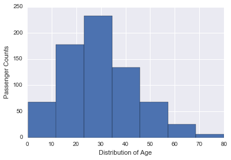

```python
# Distribution of Age
# By looking at the distribution of age, we can get a good look
# at who was riding on the Titanic.
age = manifest['Age']
age.dropna().hist(bins=7)
plt.xlabel("Distribution of Age")
plt.ylabel("Passenger Counts")
```

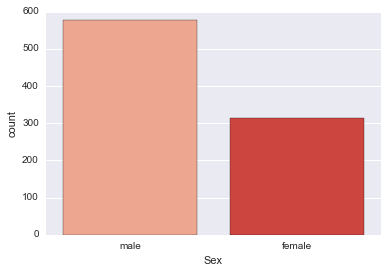

```python
# Distribution of Sex
sns.countplot(x="Sex", data=manifest, palette="Reds")
# Almost twice as many males as females!
```

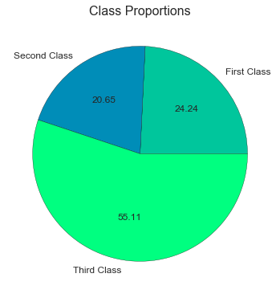

```python
# Class Proportions
# By visualizating the class distribution, we can get a good understanding
# of how the population is divided across the ship
total_pclass = manifest.groupby('Pclass')['Survived'].count()
total_pclass.plot.pie(labels=['First Class', 'Second Class', 'Third Class'],
                      colors=['#00C69C','#008DB8','#00FF80'], autopct='%.2f',
                      fontsize=12, figsize=(6, 6))
plt.title('Class Proportions', fontsize=16)
plt.ylabel("")
```

# Which independent variable has the strongest correlation to survival (dependent variable)?

Maybe there are some factors that contribute to the chance of surviving the Titantic. Let's check for a correlation between the variables.

```python
# Calculate the Correlation (Pearson's r)
def correlation(x, y):
    '''
    correlation = average of (x in standard units) times (y in standard units)
    '''
    standard_x = (x-x.mean()) / x.std(ddof=0)
    standard_y = (y-y.mean()) / y.std(ddof=0)
    xy = standard_x * standard_y
    return xy.mean()
```

```python
# Correlation between Age and Survived
age = manifest['Age']
survived = manifest['Survived']

correlation(age, survived)
```

```
-0.077982678413863
```

```python
# Correlation between Fare and Survived
fare = manifest['Fare']

correlation(fare, survived)
```

```
0.2573065223849616
```

```python
# Correlation between Pclass and Survived
pclass = manifest['Pclass']

correlation(pclass, survived)
```

```
-0.33848103596101325
```

The strongest correlation between the dependent variable 'Survived' seems to be the independent variable 'Pclass'. Let's plot the relationships.

## Dive Deeper into Investigating the Passenger Class

```python
# Group the Passenagers by Pclass
passengers_by_class = manifest.groupby(['Pclass']).mean()
```

```python
passengers_by_class.head()
```

| Pclass | PassengerId | Survived | Age | SibSp | Parch | Fare |
| --- | --- | --- | --- | --- | --- | --- |
| 1 | 461.597222 | 0.629630 | 38.233441 | 0.416667 | 0.356481 | 84.154687 |
| 2 | 445.956522 | 0.472826 | 29.877630 | 0.402174 | 0.380435 | 20.662183 |
| 3 | 439.154786 | 0.242363 | 25.140620 | 0.615071 | 0.393075 | 13.675550 |

```python
# Prevent Columns from being transformed in the Row Indexes for the Data
passengers_by_class = manifest.groupby(['Pclass'], as_index=False).mean()
```

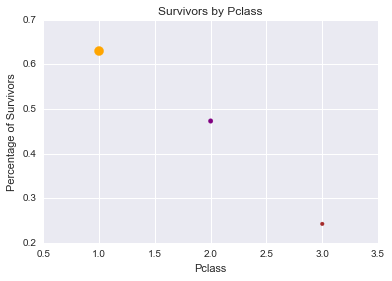

```python
# Make a scatterplot of survivors with age and pclass with fare as the bubble size.
# This will help visualize any trends related to the passenger class and highlight the
# differene in Fares between 1st Class and 3rd Class
plt.scatter(passengers_by_class['Pclass'], passengers_by_class['Survived'],
           s=passengers_by_class['Fare'], color=['orange','purple','brown'])
plt.title('Survivors by Pclass')
plt.xlabel('Pclass')
plt.ylabel('Percentage of Survivors')
```

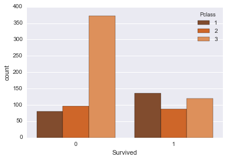

```python
# Another way to look at the data is using a Count Plot
sns.countplot(x="Survived", hue="Pclass", data=manifest, palette="Oranges_d");
# In this case, 1 = Survived
```

## Conclusions

The Survivors by Class scatter plot shows a negative relationship between the Percentage of Survivors and the Passenger Classes. Addtionally, the CountPlot details the disparity between the Passenger Classes. It it recommended that further statitistical anaylist be performed to measure whether 1st Class passengers have a significatly greater chance of survival than 3rd Class passengers.

## Limitations

There were several limitations to the exploratory analysis.

One was brought on by missing values. Removing the passengers with missing values could change the correlation between the independent variable and the dependent variable.

Another is a limiation on the conclusions we can draw from the visualizations. Without using statistical testing, we can at best use the visualizations to investigate the variables that might have a correlation visually. Only once a statistic test has been run can any verification on the connection between the variables be implied.

Additonally, there could be other factors not listed in the dataset that could have a strong correlations with survivablity, such as where they were on the ship when it hit the iceberg.

## References

http://pandas.pydata.org/pandas-docs/stable/visualization.html

http://stackoverflow.com/questions/6170246/how-do-i-use-matplotlib-autopct

http://www.shanelynn.ie/summarising-aggregation-and-grouping-data-in-python-pandas/

http://stackoverflow.com/questions/35488666/matplotlib-pandas-pie-chart-label-mistakes

http://pandas.pydata.org/pandas-docs/stable/generated/pandas.DataFrame.dropna.html

https://stanford.edu/~mwaskom/software/seaborn/tutorial/categorical.html#categorical-tutorial